# Basic Use of ceRNAnetsim

Selcen Ari

2019-11-13

# 1. Introduction

This vignette demonstrates how to analyse miRNA:Competing interactions via `ceRNAnetsim` package. The perturbations in the miRNA:target interactions are handled step by step in `ceRNAnetsim`. The package calculates and simulates regulation of miRNA:competing RNA interactions based on amounts of miRNA and the targets and interaction factors.

The `ceRNAnetsim` works by executing following steps:

- The input dataset is prepared for analysis. The first variable is arranged as competing and the second as miRNA.
- The dataset is primed with `priming_graph()` function so that it’s converted into a graph. This function makes calculations that are depended on miRNA amount, target (competing) amount and the interaction factors. It determines the efficiency of miRNA to each target and saves that values as edge data. All calculations are performed in edge data. After that, results of calculations are used in node data.
- Now, the change in expression level of either miRNA or competing RNA can be introduced with `update_variables()` or `update_how()` functions.
- The calculated values in edge are carried to node data through a helper function `update_nodes()`.
- The change is perceived as a trigger and network-wise calculations are performed.
- The trigger is used for simulation of regulations in `simulate()` or `simulate_vis()`.
- These processes can generate various outputs such as graphs or graph objects.

The workflow of `ceRNAnetsim` are shown as following:

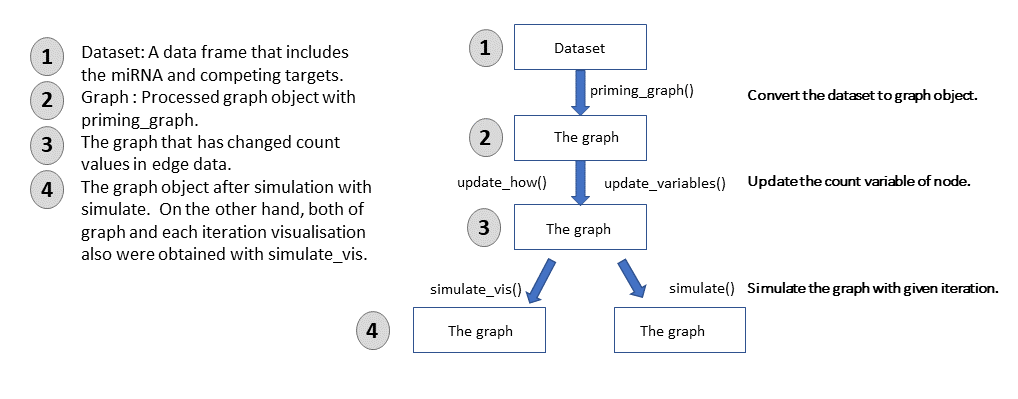

```r
library(ceRNAnetsim)
```

# 2. Installation

```r
if (!requireNamespace("BiocManager", quietly = TRUE))
    install.packages("BiocManager")
BiocManager::install("ceRNAnetsim")
```

# 3. About the data

Below is the minimal data that can be used with ceRNAnetsim.

```
#>   competing miRNA Competing_expression miRNA_expression
#> 1     Gene1  Mir1                10000             1000
#> 2     Gene2  Mir1                10000             1000
#> 3     Gene3  Mir1                 5000             1000
#> 4     Gene4  Mir1                10000             1000
#> 5     Gene4  Mir2                10000             2000
#> 6     Gene5  Mir2                 5000             2000
#> 7     Gene6  Mir2                10000             2000
```

The table is actually constructed by merging three different tables:

- gene expression data
- miRNA expression data
- miRNA:gene pairs (might **optionally** contain data about the interaction)

So, the `basic_data` table is constructed by merging following tables:

```r
gene_expression
```

```
#>   competing Competing_expression
#> 1     Gene1                10000
#> 2     Gene2                10000
#> 3     Gene3                 5000
#> 4     Gene4                10000
#> 5     Gene5                 5000
#> 6     Gene6                10000
```

```r
mirna_expression
```

```
#>   miRNA miRNA_expression
#> 1  Mir1             1000
#> 2  Mir2             2000
```

Third table should contain miRNA:gene interactions per row. The `ceRNAnetsim` will assume first column contains competing RNA names and second column to be miRNA names. If the order is different the user should indicate column names accordingly.

```r
interaction_simple
```

```
#>   competing miRNA
#> 1     Gene1  Mir1
#> 2     Gene2  Mir1
#> 3     Gene3  Mir1
#> 4     Gene4  Mir1
#> 5     Gene4  Mir2
#> 6     Gene5  Mir2
#> 7     Gene6  Mir2
```

The three tables can be joined in R (as shown below) or elsewhere to have interaction and expression data altogether in expected format.

```r
interaction_simple %>%
  inner_join(gene_expression, by = "competing") %>%
  inner_join(mirna_expression, "miRNA") -> basic_data

basic_data
```

```
#>   competing miRNA Competing_expression miRNA_expression
#> 1     Gene1  Mir1                10000             1000
#> 2     Gene2  Mir1                10000             1000
#> 3     Gene3  Mir1                 5000             1000
#> 4     Gene4  Mir1                10000             1000
#> 5     Gene4  Mir2                10000             2000
#> 6     Gene5  Mir2                 5000             2000
#> 7     Gene6  Mir2                10000             2000
```

# 4. Simulation via expression values of miRNAs and genes in `minsamp` dataset

ceRNAnetsim processes your dataset as graph object and simulates competing behaviours of targets when steady-state is perturbed via expression level changes in one or more genes. Let’s go over three steps:

## 4.1. Handle basic dataset

In first step, the expression and interaction table is converted into graph/network. `tidygraph` is used importing the data thus both node and edge data are accessible as tables if needed. `priming_graph` generates many columns in edge/node table which are mostly for internal use.

```r
#Convertion of dataset to graph.

priming_graph(basic_data, competing_count = Competing_expression, miRNA_count =miRNA_expression)
```

## 4.2. Trigger a change

`update_how` function can be used to simulate a change in the network. (If multiple chnages are aimed to be used as trigger, `update_variables()` function should be used).

In the example below, expression level of “Gene2” is increased to two-fold.

```r
priming_graph(basic_data, competing_count = Competing_expression,
              miRNA_count =miRNA_expression) %>%
  update_how(node_name = "Gene2", how=2)
```

[output not shown]

## 4.3. Simulate the changes in graph

Finally, with the help of `simulate` function, the effect of expression change (*i.e.* the trigger) on overall network. The example code advances only for 5 cycles.

```r
priming_graph(basic_data, competing_count = Competing_expression,
              miRNA_count =miRNA_expression) %>%
  update_how(node_name = "Gene2", how=2) %>%
  simulate(cycle = 5)
```

```r
priming_graph(basic_data, competing_count = Competing_expression,
              miRNA_count =miRNA_expression) %>%
  update_how(node_name = "Gene2", how=2) %>%
  simulate(cycle = 5)%>%
  as_tibble()%>%
  select(name, initial_count, count_current)
```

[output not shown]

## 4.4. A special case: knockdown

ceRNAnetsim also provides the simulation of gene knockdown in the network. In normal conditions, when a gene is up or down regulated, it is considered that amounts of gene transcripts change depended on interactions. But, the transcripts of the gene are not observed in the system when it is knocked down. To achieve this case, you just need to define `how` argument to 0 (zero) in `update_how` function.

```r
priming_graph(basic_data, competing_count = Competing_expression,
              miRNA_count =miRNA_expression) %>%
  update_how(node_name = "Gene2", how=0) %>%
  simulate(cycle = 5)
```

Briefly, ceRNAnetsim utilizes the change(s) as trigger and calculates regulation of targets according to miRNA:target and target:total target ratios.

# 5. Simulation via interaction factors in addition to expression values of miRNAs and genes in `minsamp` dataset

Minimal sample `minsamp` is processed with `priming_graph()` function in first step. This provides conversion of dataset from data frame to graph object. This step comprises of:

- The competing elements (Genes in *minsamp*) are grouped according to the miRNAs they are associated with.
- In graph object, the **optional** interaction factors are processed and graded within the groups.
- The amounts (expressions) of miRNAs are distributed according to competing:total competing ratio.
- miRNA efficiency in steady-state is calculated by taking into account of expression distribution and effecting factors. The **optional** factors might have two types of effect; 1) affinity, 2) degradation effect. Any column which has effect on affinity should be provided as a vector to `aff_factor` argument and any column that effects degradation of target RNA should be as a vector to `deg_factor` argument.

```r
minsamp
```

```
#>   competing miRNA Competing_expression miRNA_expression seed_type region
#> 1     Gene1  Mir1                10000             1000      0.43   0.30
#> 2     Gene2  Mir1                10000             1000      0.43   0.01
#> 3     Gene3  Mir1                 5000             1000      0.32   0.40
#> 4     Gene4  Mir1                10000             1000      0.23   0.50
#> 5     Gene4  Mir2                10000             2000      0.35   0.90
#> 6     Gene5  Mir2                 5000             2000      0.05   0.40
#> 7     Gene6  Mir2                10000             2000      0.01   0.80
#>   energy
#> 1    -20
#> 2    -15
#> 3    -14
#> 4    -10
#> 5    -12
#> 6    -11
#> 7    -25
```

```r
priming_graph(minsamp,
              competing_count = Competing_expression,
              miRNA_count = miRNA_expression,
              aff_factor = c(energy, seed_type),
              deg_factor = region)
```

In the processed data, the values are carried as node variables and many more columns are initialized which are to be used in subsequent steps.

## 5.1. Change expression level of one or more nodes in the graph

In the steady-state, the miRNA degradation effect on gene expression is assumed to be stable (*i.e.* in equilibrium). But, if one or more nodes have altered expression level, the system tends to reach steady-state again.

The `ceRNAnetsim` package utilizes two methods to simulate change in expression level, `update_how()` and `update_variables()` functions provide unstable state from which calculations are triggered to reach steady-state.

- Method 1: change expression level of single node

If updating expression level of single node is desired then `update_how()` function should be used. In the example below, expression level of Gene4 is increased 2-fold.

```r
minsamp %>%
   priming_graph(competing_count = Competing_expression,
                 miRNA_count = miRNA_expression,
                 aff_factor = c(energy, seed_type),
                 deg_factor = region) %>%
   update_how(node_name = "Gene4", how = 2) %>%
   activate(edges)%>%
   # following line is just for focusing on necessary
   # columns to see the change in edge data
   select(3:4,comp_count_pre,comp_count_current)
```

[output not shown]

- Method 2: update expression level of all nodes

The `update_variables()` function uses an external dataset which has number of rows equal to number of nodes in graph. The external dataset might include changed and unchanged expression values for each node.

Load the `new_count` dataset (provided with package sample data) in which expression level of Gene2 is increased 2 fold (from 10,000 to 20,000). Note that variables of the dataset included updated variables must be named as “Competing”, “miRNA”, “miRNA_count” and “Competing_count”.

```r
data(new_counts)
new_counts
```

```
#>   Competing miRNA Competing_count miRNA_count
#> 1     Gene1  Mir1           10000        1000
#> 2     Gene2  Mir1           20000        1000
#> 3     Gene3  Mir1            5000        1000
#> 4     Gene4  Mir1           10000        1000
#> 5     Gene4  Mir2           10000        2000
#> 6     Gene5  Mir2            5000        2000
#> 7     Gene6  Mir2           10000        2000
```

`update_variables()` function replaces the existing expression values with new values. The function checks for updates in all rows after importing expression values, thus it’s possible to introduce multiple changes at once.

```r
minsamp %>%
   priming_graph(competing_count = Competing_expression,
                 miRNA_count = miRNA_expression,
                 aff_factor = c(energy, seed_type),
                 deg_factor = region) %>%
   update_variables(current_counts = new_counts)
```

## 5.2. Update the node variables with edge variables.

The functions `update_variables()` and `update_how()` updates edge data. In these functions, `update_nodes()` function is applied in order to reflect changes in edge data over to node data. In other words, if there’s a change in edge data, nodes can be updated accordingly with `update_nodes()` function.

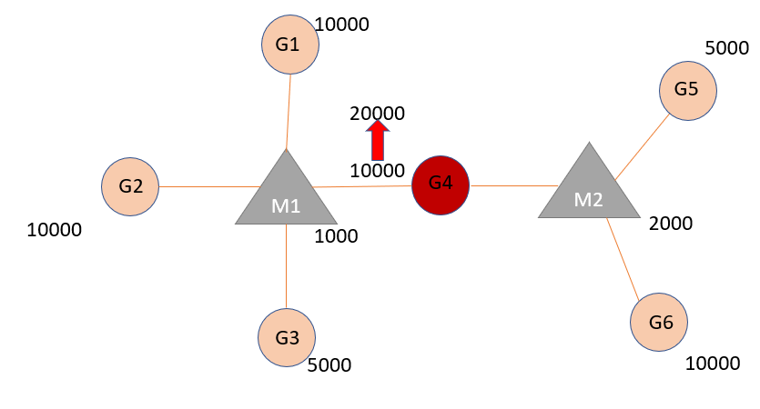

```r
minsamp %>%
  priming_graph(competing_count = Competing_expression,
                miRNA_count = miRNA_expression,
                aff_factor = c(energy, seed_type),
                deg_factor = region) %>%
  update_how("Gene4", how = 2)
# OR
# minsamp %>%
#   priming_graph(competing_count = Competing_expression,
#                 miRNA_count = miRNA_expression,
#                 aff_factor = c(energy, seed_type),
#                 deg_factor = region) %>%
#   update_variables(current_counts = new_counts)
```

## 5.3. Simulate the model

Change in expression level of one or more nodes will trigger a perturbation in the system which will effect neighboring miRNA:target interactions. The effect will propagate and iterate over until it reaches steady-state.

With `simulate()` function the changes in the system, are calculated iteratively. For example, in the example below, simulation will proceed ten cycles only. In simulation of the regulation, the important argument is `threshold` which provides to specify absolute minimum amount of change required to be considered changed element as up or down.

```r
minsamp %>%
  priming_graph(competing_count = Competing_expression,
                miRNA_count = miRNA_expression,
                aff_factor = c(energy, seed_type),
                deg_factor = region) %>%
  update_how("Gene4", how = 2) %>%
  simulate(cycle=10) #threshold with default 0.
```

`simulate()` saves the expression level of previous iterations in list columns in edge data. The changes in expression level throughout the simulate cycles are accessible with standard `dplyr` functions. For example:

```r
minsamp %>%
   priming_graph(competing_count = Competing_expression,
                 miRNA_count = miRNA_expression,
                 aff_factor = c(energy, seed_type),
                 deg_factor = region) %>%
   update_how("Gene4", how = 2) %>%
   simulate(cycle=10) %>%
   activate(edges) %>%       #from tidygraph package
   select(comp_count_list, mirna_count_list) %>%
   as_tibble()
```

[output not shown]

[output not shown]

```r
minsamp %>%
  priming_graph(competing_count = Competing_expression,
                miRNA_count = miRNA_expression,
                aff_factor = c(energy, seed_type),
                deg_factor = region) %>%
  update_how("Gene4", how = 2) %>%
  simulate(cycle=3, threshold = 1)
```

## 5.4. Visualisation of the graph

The `vis_graph()` function is used for visualization of the graph object. The initial graph object (steady-state) is visualized as following:

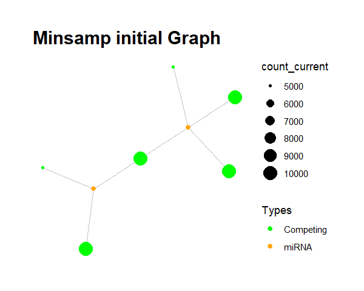

```r
minsamp %>%
   priming_graph(competing_count = Competing_expression,
                 miRNA_count = miRNA_expression,
                 aff_factor = c(energy, seed_type),
                 deg_factor = region) %>%
   vis_graph(title = "Minsamp initial Graph")
```

Also, The graph can be visualized at any step of process, for example, after simulation of 3 cycles the graph will look like:

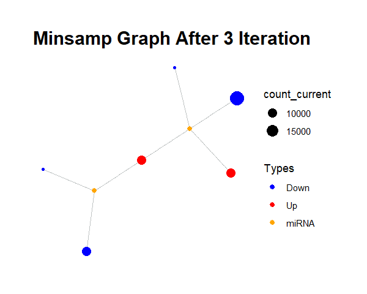

```r
minsamp %>%
   priming_graph(competing_count = Competing_expression,
                 miRNA_count = miRNA_expression,
                 aff_factor = c(energy, seed_type),
                 deg_factor = region) %>%
   update_variables(current_counts = new_counts) %>%
   simulate(3) %>%
   vis_graph(title = "Minsamp Graph After 3 Iteration")
```

On the other hand, the network of each step can be plotted individually by using `simulate_vis()` function. `simulate_vis()` processes the given network just like `simulate()` function does while saving image of each step.

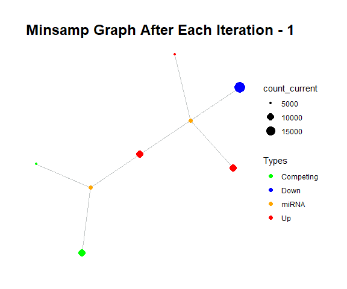

Minsamp with 3 iteration

```r
minsamp %>%
   priming_graph(competing_count = Competing_expression,
                 miRNA_count = miRNA_expression,
                 aff_factor = c(energy, seed_type),
                 deg_factor = region) %>%
   update_variables(current_counts = new_counts) %>%
   simulate_vis(3, title = "Minsamp Graph After Each Iteration")
```

Note: Animated gif above was generated by online service. Actually, workflow gives the frames which include condition of each iteration. Note that you must use a terminal or online service, if you want to generate the animated gif.

See the other vignettes for more information.